# A regresszió feltételeinek vizsgálata

y ~ x kétváltozós regresszió

# 1 A feladat célja

A feladatban az `xy.xlsx` adatállományban található `x` és `y` változó kapcsolatát vizsgálom kétváltozós lineáris regresszióval. Ezután megnézem, hogy a regresszió feltételei közül melyek vizsgálhatók a rendelkezésre álló elemszám mellett.

# 2 Szükséges csomagok

```r
library(readxl)
library(knitr)
```

# 3 Adatok beolvasása

```r
data <- read_xlsx("xy.xlsx")
kable(data)
```

| x | y |
| --- | --- |
| 0.00 | 0.58 |
| 0.05 | 0.70 |
| 0.08 | 2.88 |
| 0.10 | 3.42 |
| 0.12 | 3.53 |
| 0.15 | 5.21 |

Az adatállományban összesen 6 megfigyelés található. Ez nagyon kis elemszám, ezért a regresszió feltételeinek vizsgálatánál ezt figyelembe kell venni.

# 4 A regressziós modell

A vizsgált modell:

$$y = \beta_0 + \beta_1 x + u$$

ahol `y` a függő változó, `x` a magyarázó változó, `u` pedig a hibatag.

```r
fit <- lm(y ~ x, data = data)
summary(fit)
```

```
##
## Call:
## lm(formula = y ~ x, data = data)
##
## Residuals:
##       1       2       3       4       5       6
##  0.5280 -0.9528  0.2667  0.1664 -0.3639  0.3556
##
## Coefficients:
##             Estimate Std. Error t value Pr(>|t|)
## (Intercept)  0.05196    0.50403   0.103   0.9229
## x           32.01651    5.22658   6.126   0.0036 **
## ---
## Signif. codes:  0 '***' 0.001 '**' 0.01 '*' 0.05 '.' 0.1 ' ' 1
##
## Residual standard error: 0.6214 on 4 degrees of freedom
## Multiple R-squared:  0.9037, Adjusted R-squared:  0.8796
## F-statistic: 37.52 on 1 and 4 DF,  p-value: 0.003598
```

A regresszió eredménye alapján a modell szignifikáns, mert az F-próbához tartozó p-érték 0,05-nél kisebb. Kétváltozós regresszió esetén ugyanerre az eredményre jutunk az `x` változó együtthatójának t-próbájával is.

Az `x` változó regressziós együtthatója pozitív, tehát az `x` növekedésével a becsült `y` értéke is nő. A modell determinációs együtthatója körülbelül 0,904, vagyis a modell az `y` változó szóródásának körülbelül 90,4%-át magyarázza.

# 5 A regresszió feltételeinek vizsgálata

Az órai anyag alapján a lineáris regresszió fő feltételei a következők:

1. a hibatag várható értéke 0;
2. a hibatag varianciája állandó, vagyis nincs heteroszkedaszticitás;
3. a hibatagok függetlenek egymástól;
4. az `x` változó és a hibatag független;
5. a hibatag normális eloszlást követ.

## 5.1 A hibatag várható értéke

Konstanst tartalmazó lineáris regressziónál a reziduumok átlaga az illesztésből adódóan gyakorlatilag nulla.

```r
mean(resid(fit))
```

```
## [1] 2.775558e-17
```

A kapott érték kerekítési hibától eltekintve 0, ezért ez a feltétel teljesül.

## 5.2 A normalitás vizsgálata

Az órai anyag szerint a reziduumok normalitását Shapiro-Wilk-próbával lehet vizsgálni, azonban ehhez legalább 30 megfigyelés szükséges ahhoz, hogy a vizsgálat megbízható legyen.

A jelen adatállományban csak 6 megfigyelés van, ezért a Shapiro-Wilk-próbát **nem végzem el**. Ilyen kis elemszám mellett az eredményből nem lehetne megfelelő biztonsággal következtetni a normalitás teljesülésére.

## 5.3 A szóráshomogenitás vizsgálata

A regresszió másik fontos feltétele, hogy a hibatag varianciája állandó legyen. Az órai anyag szerint ezt statisztikai próbákkal is lehet vizsgálni, de a jelen esetben mindössze 6 megfigyelés áll rendelkezésre.

Ilyen kis elemszám mellett a reziduumok szóródására vonatkozó formális vizsgálat eredménye nem lenne megbízható, ezért itt nem végzek külön homogenitási próbát. A reziduumábrát viszont meg lehet nézni, de az órai példa alapján ilyen kevés adatpontból az ábra sem alkalmas biztos következtetés levonására.

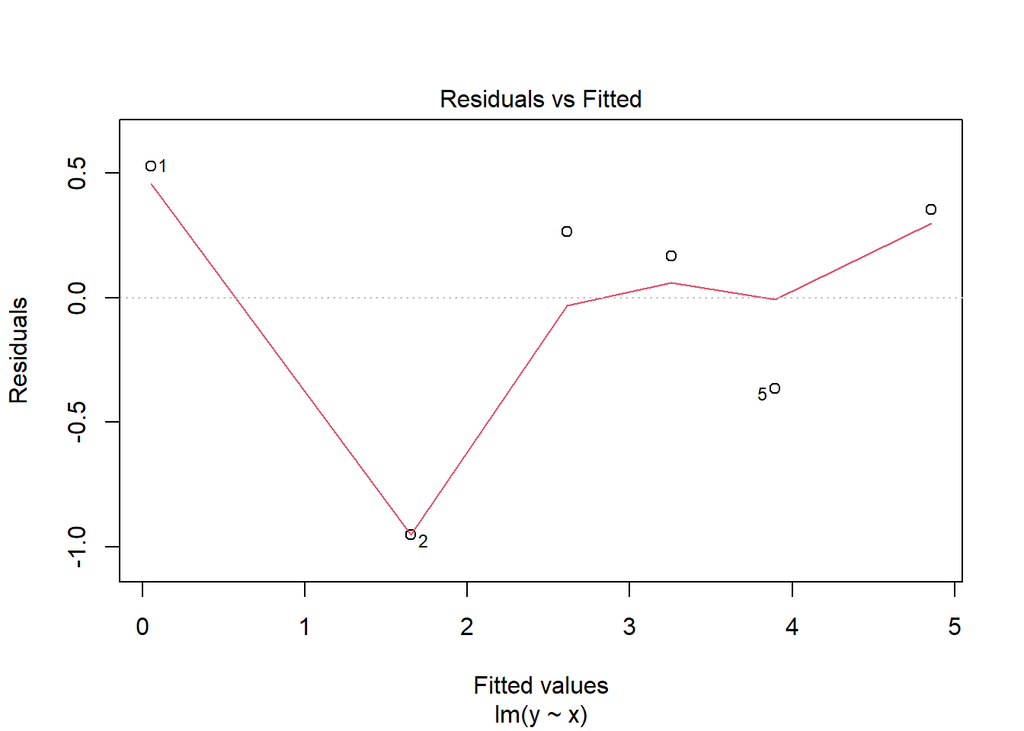

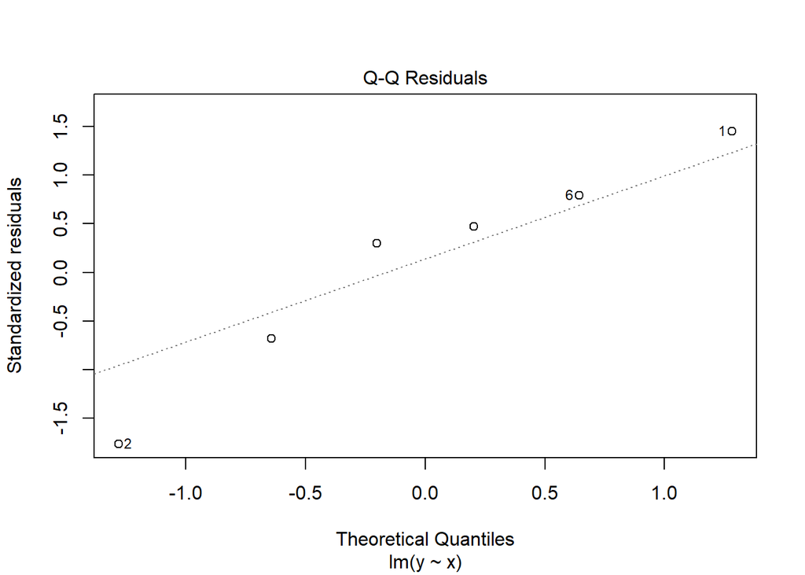

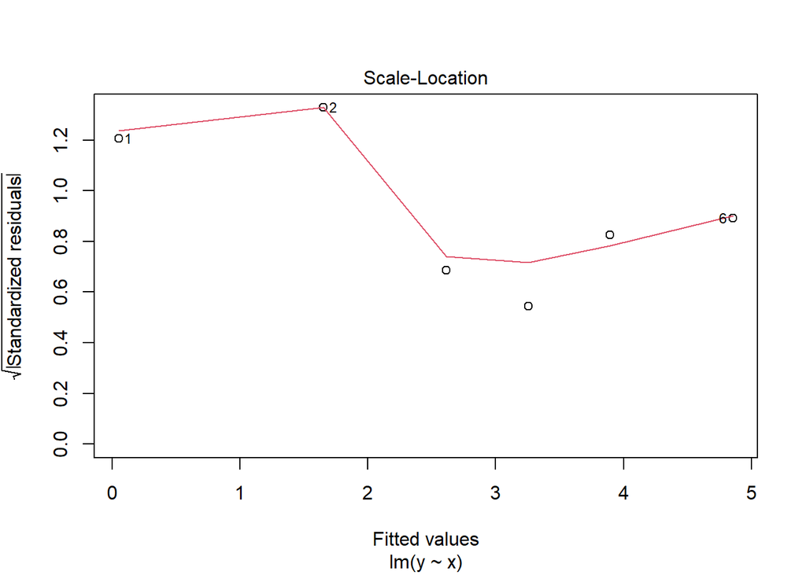

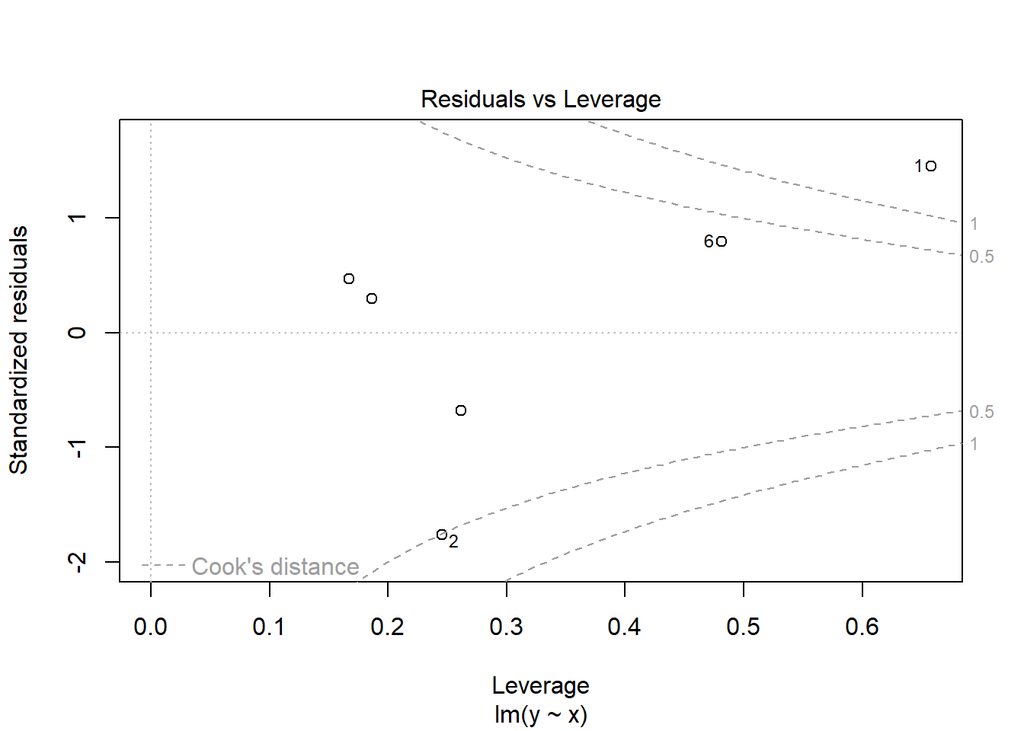

```r
plot(fit)
```

## 5.4 A hibatagok függetlensége

Az autokorreláció elsősorban idősoros adatoknál jelent problémát. A jelen adatállomány nem idősor, ezért ezt a feltételt külön teszttel nem vizsgálom.

## 5.5 Az x és a hibatag függetlensége

Az órai anyag szerint ez a feltétel akkor tekinthető teljesülőnek, ha az `x` nem véletlen változóként szerepel, illetve a kapcsolat megfelelően lineáris. Erre ebben a kis mintában külön statisztikai tesztet nem végzünk.

# 6 Következtetés

A `y ~ x` lineáris regresszió kiszámítható a hat megfigyelésből. A modell és az `x` változó is szignifikáns, és a determinációs együttható magas, körülbelül 90,4%.

A regresszió feltételeinek ellenőrzése azonban az elemszám miatt csak korlátozottan lehetséges. A reziduumok átlaga az illesztésből következően közel nulla. A normalitást az órán tanult Shapiro-Wilk-próbával ilyen kis minta mellett nem vizsgáljuk, mert az órai anyag legalább 30 megfigyelést ír elő. A szóráshomogenitás formális vizsgálata és a grafikus ellenőrzés sem adna megbízható eredményt mindössze hat adatpontból. Az autokorreláció vizsgálata pedig nem indokolt, mert nem idősoros adatokkal dolgozunk.

Ezért bár a regressziós kapcsolat erősnek és szignifikánsnak látszik, a regresszió alkalmazhatósági feltételeinek teljesülését ilyen kis elemszám mellett nem lehet megfelelően igazolni, így az eredményt óvatosan kell értelmezni.